# Collect reproductivity traits

## 3.2 Fecundity

Read in data from vulnerability project and fishbase/sealifebase. Examine potential for variables to be used to gapfill for max fecundity. Min and max both have >2400 observations; mean has 133.

```r
fields <- c('fecun')
fecund_df_raw <- get_fb_slb(fxn = fecundity,
                     keep_cols = fields, keep_fxn = contains,
                     drop_cols = '_ref', drop_fxn = ends_with) %>%
  select(db, spec_code, species, starts_with('fecun'))
# summary(fecund_df_raw)
# fecund_df_raw %>% summarize(across(starts_with('fecun'), .fns = ~sum(!is.na(.x))))

lm_fec1 <- lm(fecundity_max ~ fecundity_min, data = fecund_df_raw); coef_fec1 <- lm_fec1$coefficients[2]
# summary(lm_fec1)
### slope = 2.92, p << .001, adj.R^2 = .83
lm_fec2 <- lm(fecundity_max ~ fecundity_mean, data = fecund_df_raw); coef_fec2 <- lm_fec2$coefficients[2]
# summary(lm_fec2)
### slope = 1.15, p << .001, adj.R^2 = .95

fecund_df <- fecund_df_raw %>%
  mutate(max_fecundity = case_when(!is.na(fecundity_max) ~ fecundity_max,
                             !is.na(fecundity_mean) ~ fecundity_mean * coef_fec2,
                             !is.na(fecundity_min) ~ fecundity_min * coef_fec1,
                             TRUE ~ NA_real_)) %>%
  select(db, spec_code, species, max_fecundity) %>%
  group_by(db, spec_code, species) %>%
  summarize(max_fecundity = mean(max_fecundity), .groups = 'drop') %>%
  right_join(spp_from_worms, by = 'species')

table(fecund_df$db)
```

```
##
##    fb   slb
## 18394 57379
```

```r
fecund_df %>% filter(!is.na(max_fecundity)) %>% n_distinct(.$species)
```

```
## [1] 1161
```

Even with all this, we get only 1161 distinct species, guessing some of which are freshwater.

```r
f_vals <- c('<1', '1-2' , '2-5', '5-10', '10-20', '20-50', '50-100', '100-1000', '1000-10000', '>10000')

fecund_vuln <- get_vuln_traits() %>%
  filter(trait == 'fecundity') %>%
  mutate(trait_value = factor(trait_value,
                              levels = f_vals),
         bin = as.integer(trait_value))

fecund_vuln_gf <- downfill(fecund_vuln)
```

### 3.2.1 Calculate bin values

Use the numeric fecundity values to assign a mean max_fecundity value to each of the categorical bins. Even log-transformed, there is still a lot of skew. Filter out only those observations that match with the range, then log transform and calc the mean/sd.

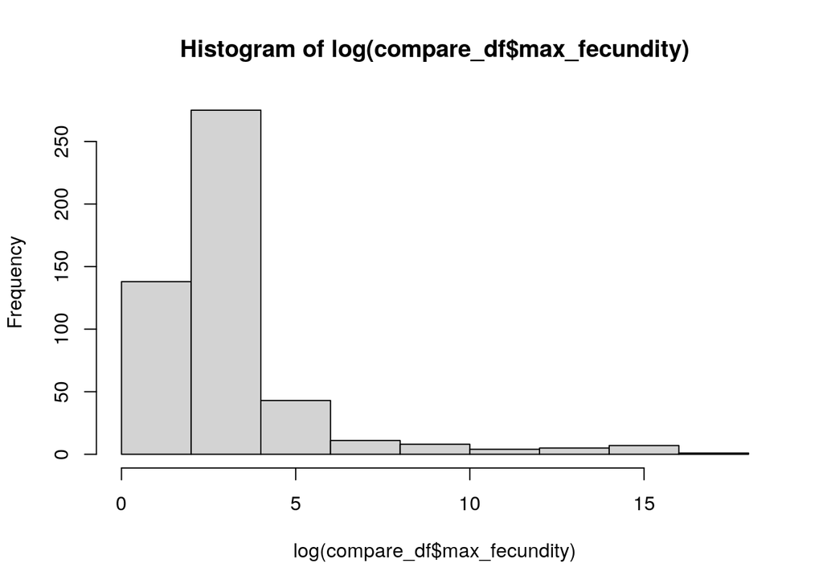

```r
### compare vulnerability data to fb/slb data

vuln_and_fb <- fecund_vuln_gf %>%
  full_join(fecund_df)

# f_vals <- c('<1', '1-2' , '2-5', '5-10', '10-20', '20-50', '50-100', '100-1000', '1000-10000', '>10000')
compare_df <- vuln_and_fb %>%
  filter(!is.na(trait_value) & !is.na(max_fecundity)) %>%
  mutate(match = (bin == 1 & max_fecundity <= 1) |
                 (bin == 2 & between(max_fecundity, 1, 2)) |
                 (bin == 3 & between(max_fecundity, 2, 5)) |
                 (bin == 4 & between(max_fecundity, 5, 10)) |
                 (bin == 5 & between(max_fecundity, 10, 20)) |
                 (bin == 6 & between(max_fecundity, 20, 50)) |
                 (bin == 7 & between(max_fecundity, 50, 100)) |
                 (bin == 8 & between(max_fecundity, 100, 1000)) |
                 (bin == 9 & between(max_fecundity, 1000, 10000)) |
                 (bin == 10 & max_fecundity >= 10000))

hist(log(compare_df$max_fecundity))
```

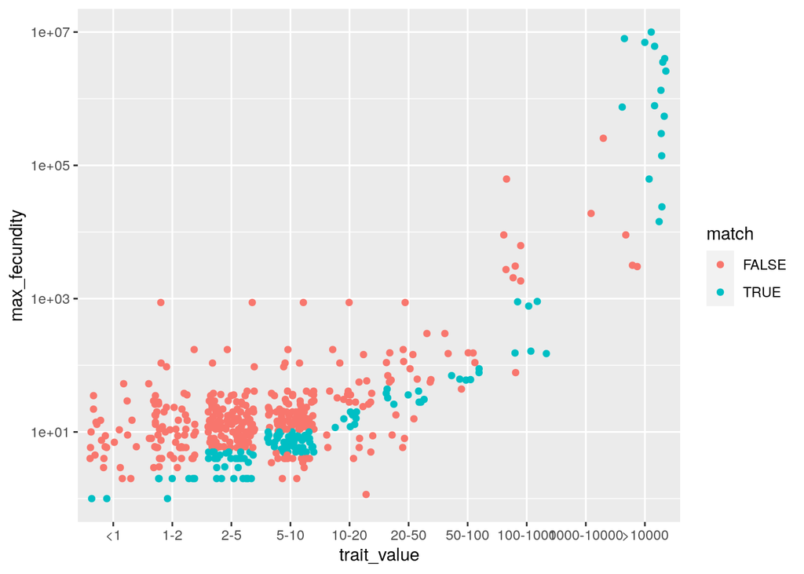

```r
### 207 spp with values in both
ggplot(compare_df, aes(x = trait_value, y = max_fecundity, color = match)) +
  geom_jitter() +
  scale_y_log10()
```

```r
summary(lm(bin ~ log10(max_fecundity), data = compare_df %>% filter(match)))
```

```
##
## Call:
## lm(formula = bin ~ log10(max_fecundity), data = compare_df %>%
##     filter(match))
##
## Residuals:
##      Min       1Q   Median       3Q      Max
## -1.92604 -0.68723 -0.06783  0.42905  2.32270
##
## Coefficients:
##                      Estimate Std. Error t value Pr(>|t|)
## (Intercept)           2.92604    0.10945   26.73   <2e-16 ***
## log10(max_fecundity)  1.26432    0.04651   27.18   <2e-16 ***
## ---
## Signif. codes:  0 '***' 0.001 '**' 0.01 '*' 0.05 '.' 0.1 ' ' 1
##
## Residual standard error: 0.9243 on 126 degrees of freedom
## Multiple R-squared:  0.8543, Adjusted R-squared:  0.8532
## F-statistic: 738.9 on 1 and 126 DF,  p-value: < 2.2e-16
```

```r
summary_bins <- compare_df %>%
  filter(match) %>%
  group_by(trait_value) %>%
  summarize(mean_log_max_fecundity = mean(log10(max_fecundity)),
            sd_log_max_fecundity = sd(log10(max_fecundity)))

novel_df <- vuln_and_fb %>%
  filter(is.na(trait_value) & !is.na(max_fecundity))
### 952 spp with FB/SLB max fecundity but no vuln fecundity

max_fecund_df <- vuln_and_fb %>%
  left_join(summary_bins, by = 'trait_value') %>%
  mutate(log_max_fecund = ifelse(!is.na(max_fecundity), log10(max_fecundity), mean_log_max_fecundity)) %>%
  group_by(db, spec_code, kingdom, phylum, class, order, family, genus, species, gapfill, match_rank) %>%
  summarize(log_max_fecund = mean(log_max_fecund, na.rm = TRUE),
            sd_log_max_fecund = sqrt(sum(sd_log_max_fecundity^2, na.rm = TRUE)), .groups = 'drop')


max_fecund_gf <- max_fecund_df %>%
  gapfill_up_down(col = 'log_max_fecund', keep = keep_gf_levels)
```

## 3.3 Parental investment

Read in data from vulnerability project and fishbase/sealifebase. Here we have data on parental investment (maternal/paternal/both/neither) and protection mode (bearers/guarders/non-guarders). Assign protection mode from bearers (high) to non-guarders (low). Because the parental investment score here only covers FishBase, and is not comparable to that in the vulnerability traits data (which is closer to the protection trait), let’s skip it in favor of the post-birth dependence trait in the vulnerability traits data.

```r
fields <- c('parental', 'guild')

reprod_df_raw <- get_fb_slb(fxn = reproduction,
                     keep_cols = fields, keep_fxn = contains,
                     drop_cols = '_ref', drop_fxn = ends_with)
# summary(reprod_df_raw)

# x <- reprod_df_raw %>% filter(!is.na(rep_guild1) | !is.na(parental_care))

# parent_df <- reprod_df_raw %>%
#   mutate(parental_score = case_when(parental_care == 'none' ~ 0,
#                                   str_detect(parental_care, 'aternal') ~ 1,
#                                   parental_care == 'biparental' ~ 2)) %>%
#   select(db, spec_code, species, parental_score) %>%
#   group_by(db, spec_code, species) %>%
#   summarize(parental_score = mean(parental_score), .groups = 'drop') %>%
#   right_join(spp_from_worms, by = 'species')
#
# parent_df %>% filter(!is.na(parental_score)) %>% select(db, parental_score) %>% table()

protect_df <- reprod_df_raw %>%
  mutate(rep_guild1 = factor(rep_guild1, levels = c('nonguarders', 'guarders', 'bearers')),
         protect_score = as.integer(rep_guild1)) %>%
  select(db, spec_code, species, protect_score) %>%
  group_by(db, spec_code, species) %>%
  summarize(protect_score = mean(protect_score), .groups = 'drop') %>%
  right_join(spp_from_worms, by = 'species')

protect_df %>% filter(!is.na(protect_score)) %>% select(db, protect_score) %>% table()
```

```
##      protect_score
## db        1     2     3
##   fb   4333  1400  1402
##   slb  3177   361 11160
```

For the vulnerability data, parental investment is based on: (egg-layer unattended, egg-layer, live birth/egg care, spawner) - which seems comparable to protection mode above. Post-birth/hatching parental dependence is a time scale: less than a week up to more than a year.

```r
parent_vuln <- get_vuln_traits() %>%
  filter(str_detect(trait, 'parental_investment')) %>%
  mutate(parent_score = case_when(str_detect(trait_value, 'spawn|unattend') ~ 0,
                                trait_value == 'egg-layer' ~ 1,
                                trait_value == 'live birth/egg care' ~ 2))

parent_vuln_gf <- downfill(parent_vuln)

depend_vuln <- get_vuln_traits() %>%
  filter(trait == 'post_birth_hatching_parental_dependence') %>%
  mutate(trait_value = factor(trait_value, levels = c('na', '<week', 'week-month', 'month-year', '>year')),
         depend_score = as.double(trait_value) - 1)
           ### so "na" is 0 dependence, i.e., no post-birth care

depend_vuln_gf <- downfill(depend_vuln)
```

### 3.3.1 Compare datasets

First compare the FB/SLB parental protection traits to those in the vulnerability dataset. It appears that the `protect_score` from FishBase captures more differences in the middle values, so use that as the preferred dataset, filling in with `parent_score` from the vulnerability traits.

Here we also incorporate length of post-birth/hatching dependence from the vulnerability traits.

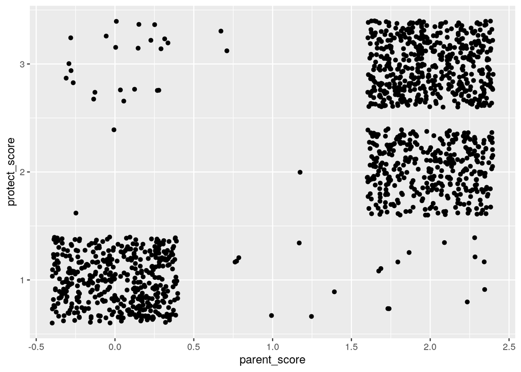

```r
vuln_and_fb <- protect_df %>%
  full_join(parent_vuln_gf)

ggplot(vuln_and_fb, aes(x = parent_score, y = protect_score)) +
  geom_jitter()
```

```r
parental_protect_df <- vuln_and_fb %>%
  mutate(protect_score = ifelse(is.na(protect_score), parent_score, protect_score)) %>%
  group_by(db, spec_code, kingdom, phylum, class, order, family, genus, species, gapfill, match_rank) %>%
  summarize(protect_score = mean(protect_score, na.rm = TRUE), .groups = 'drop')

parental_protect_gf <- parental_protect_df %>%
  gapfill_up_down(col = 'protect_score', keep = keep_gf_levels)

parental_depend_gf <- depend_vuln_gf %>%
  group_by(class, order, family, genus, species, gapfill, match_rank) %>%
  summarize(depend_score = mean(depend_score, na.rm = TRUE), .groups = 'drop') %>%
  full_join(protect_df %>% select(-protect_score)) %>%
  gapfill_up_down(col = 'depend_score', keep = keep_gf_levels)
```

## 3.4 Planktonic larval duration

From the vulnerability traits, we can identify PLD as a potential variable for discerning functional groups.

```r
pld_vals <- c('not larvae', '<1day', '<1week', '<1month', '<4months', '4months-1yr', '>1yr')

pld_vuln <- get_vuln_traits() %>%
  filter(str_detect(trait, 'planktonic_larval_duration')) %>%
  mutate(trait_value = factor(trait_value, levels = pld_vals),
         pld_score = as.integer(trait_value) - 1) %>%
  group_by(taxon, spp_gp) %>%
  summarize(pld_score = mean(pld_score, na.rm = TRUE), .groups = 'drop')

pld_vuln_downfill <- downfill(pld_vuln)

pld_vuln_gf <- pld_vuln_downfill %>%
  full_join(protect_df %>% select(-protect_score)) %>%
  gapfill_up_down(col = 'pld_score', keep = keep_gf_levels)
```

## 3.5 Put them all together and PCA

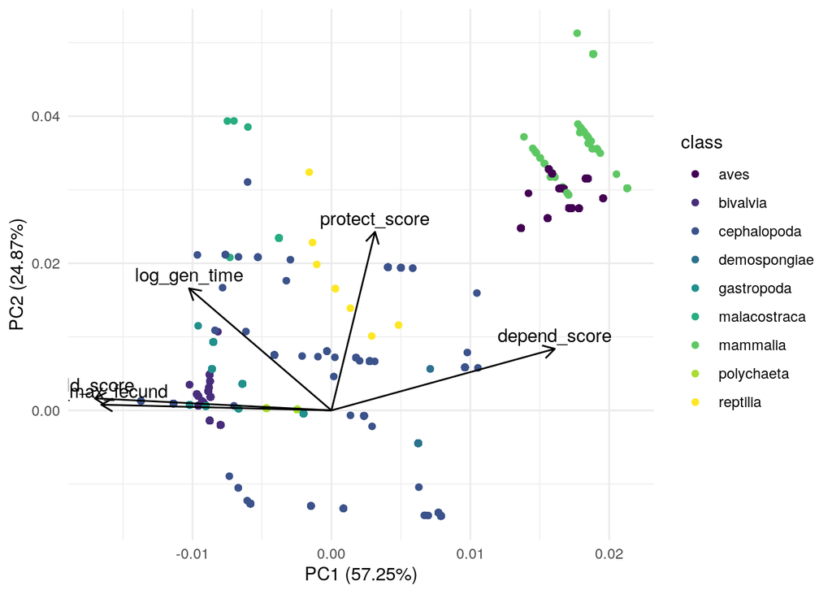

```r
repr_df_all <- pld_vuln_gf %>%
  full_join(gen_time_gf %>% select(-db, -spec_code)) %>%
  full_join(max_fecund_gf %>% select(-db, -spec_code)) %>%
  full_join(parental_protect_gf %>% select(-db, -spec_code)) %>%
  full_join(parental_depend_gf %>% select(-db, -spec_code))

repr_df_drop_na <- repr_df_all %>%
  select(-db, -ends_with(c('_sd', '_nspp')), -spec_code) %>%
  distinct() %>%
  drop_na()

repr_pca <- repr_df_drop_na %>%
  select(where(is.numeric)) %>%
  scale() %>%
  prcomp()

autoplot(repr_pca,
         data = repr_df_drop_na,
         loadings = TRUE,
         colour = 'class',
         loadings.label = TRUE,
         loadings.colour = "black",
         loadings.label.colour = "black",
         loadings.label.vjust = -0.5
         ) +
  scale_color_viridis_d() +
  theme_minimal()
```

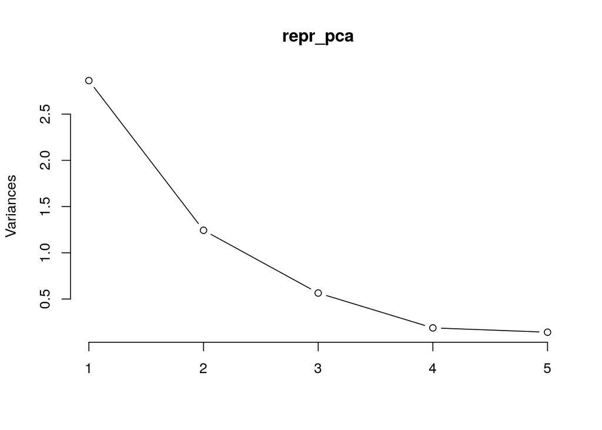

```r
# Variance explained by each PC
screeplot(repr_pca, type = "lines")
```

```r
# See the loadings (weighting for each principal component)
repr_pca$rotation %>% round(3)
```

```
##                   PC1   PC2    PC3    PC4    PC5
## pld_score      -0.556 0.054 -0.064 -0.508 -0.652
## log_gen_time   -0.335 0.542  0.738  0.049  0.219
## log_max_fecund -0.541 0.025 -0.281  0.783 -0.120
## protect_score   0.102 0.793 -0.568 -0.137  0.140
## depend_score    0.525 0.273  0.224  0.327 -0.702
```

```r
round(repr_pca$sdev^2/sum(repr_pca$sdev^2)*100)
```

```
## [1] 57 25 11  4  3
```

Write out the results:

```r
repr_pca_df <- repr_df_drop_na %>%
  select(kingdom:species) %>%
  bind_cols(as.data.frame(repr_pca$x[, 1:2])) %>%
  rename(repr_pc1 = PC1, repr_pc2 = PC2)

repr_out_df <- repr_df_all %>%
  select(db, spec_code, kingdom:species) %>%
  left_join(repr_pca_df) %>%
  mutate(db = ifelse(is.na(db), 'worms', db))

write_csv(repr_out_df, here('_data/traits_grouping/trait_reproduction_pca.csv'))
```